# Demo notebook for Jupyter - openBIS integration

This notebook demonstrates how we can connect to the openBIS server, download some data, analyze the data and then save the results in openBIS.

## Prepare an environment

- Install packages

  ```
  $ pip install --upgrade numpy matplotlib scikit-image
  ```

- Install jupyter-openbis extension

  ```
  $ pip install --upgrade jupyter-openbis-extension
  $ jupyter serverextension enable --py jupyter-openbis-server
  ```

When `jupyter-openbis-extension` has been installed and enabled, you can see these three extra buttons in the toolbar.

[figure not shown]

## Configure the connection

- Click on `configure openBIS connections` button in the toolbar
- Enter
  - Name: openbis-training
  - URL: https://openbis-training.ethz.ch/openbis/webapp/eln-lims/
  - Your username and password
  - Click `Create`
- After the status shows `connected`, choose this connection and click `Choose connection`

## Download a dataset

- Go to the lab notebook
  - Click on the dataset > `More...` > `Show Identification Info`
    - Copy the path under `Object:`, e.g., /JARUNANP_JARUNANP/TRAINING/JUPYTER-DEMO
- Go to the Jupyter notebook
  - Click on `Download openBIS datasets` button in the toolbar
  - Paste the path to `Entity Identifier/permid:`
  - Click `show datasets`
  - Select the dataset and click `Download`

## Import required modules

```python
import os
import numpy as np
import matplotlib.pyplot as plt
from skimage.io import imread
from skimage.morphology import reconstruction, remove_small_objects
from skimage.measure import label, regionprops

%matplotlib inline
```

## Read and display the data

Before reading the image, define your dataset's code, e.g., 20201116203541033-438

```python
workdir = os.getcwd()
datasetcode = '20201116203541033-438'
path_to_dataset = os.path.join(workdir, datasetcode, 'original/blobs.tif')
path_to_dataset
```

```
'/home/jarunanp/siswork/sis-projects/20_08_openbis_training/openbis-training/Jupyter/20201116203541033-438/original/blobs.tif'
```

```python
img = imread(path_to_dataset)
```

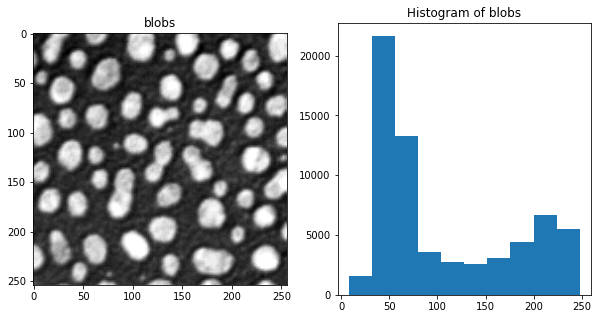

```python
fig = plt.figure(figsize=(10,5))
fig.add_subplot(121)
plt.imshow(img, cmap='gray')
plt.title('blobs')
fig.add_subplot(122)
plt.hist(img.ravel(), bins=10)
plt.title('Histogram of blobs')
plt.show()
```

## Process the data

Let's say our analysis task is to segment the white blobs from the dark background. We will first set a threshold to binarize the image. Then we perform some further image processing to refine the results. Finally, we label the segmented blobs and measure their size.

```python
intensity_threshold = 150
binary = img > intensity_threshold
```

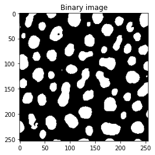

```python
plt.imshow(binary, cmap='gray')
plt.title('Binary image')
```

Fill the small holes in the white blobs.

```python
seed = np.copy(binary)
seed[1:-1, 1:-1] = binary.max()
filled = reconstruction(seed, binary, method='erosion')
```

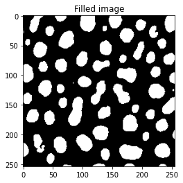

```python
plt.imshow(filled, cmap='gray')
plt.title('Filled image')
```

Remove some small, spurious blobs.

```python
removed_small = remove_small_objects(filled.astype(bool), min_size=20)
```

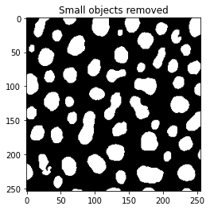

```python
plt.imshow(removed_small, cmap='gray')
plt.title('Small objects removed')
```

Label the objects found.

```python
label_img = label(removed_small, connectivity=img.ndim)
```

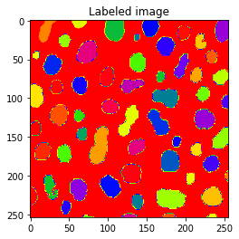

```python
plt.imshow(label_img*10, cmap='prism')
plt.title('Labeled image')
```

Get properties of the detected objects.

```python
props = regionprops(label_img)
area = np.array([x.area for x in props])
```

```python
print('Found %d blobs.' % (len(area)))
print('Area min: %1.0f pixels' % (np.min(area)))
print('Area max: %1.0f pixels' % (np.max(area)))
print('Area mean: %1.0f pixels' % (np.mean(area)))
```

```
Found 59 blobs.
Area min: 34 pixels
Area max: 820 pixels
Area mean: 333 pixels
```

## Upload the notebook and data to openBIS

- Select `File` > `Save and checkpoint` to save your work
- Select `File` > `Download as` > `HTML` to create a static version of the notebook
- Click `upload Notebook and Data to openBIS` in the menu toolbar and fill in the dataset information
  - **choose a dataSet type**: ANALYSIS_NOTEBOOK
  - **Name**: Demo1
  - **Notes**: Results of Demo1
  - **enter a sample/experiment identifier to attach this dataSet to**: /JARUNANP_JARUNANP/TRAINING/JUPYTER-DEMO
  - uncheck all **Parent Datasets**
  - select **Files to upload**:
    - Jupyter_Demo_Notebook.html
    - Jupyter_Demo_Notebook.ipynb